# Lesson 5: Gibbs sampling

Siim Põldre

9 12 2020

## Lesson 5.1

Siiani oleme demonstreerinud MCMC algoritmi ühe parameetri jaoks. Kui me otsime järeljaotust (*posterior distribution*) aga mitme parameetri jaoks ja sellel posterior jaotusel pole standardvormi, siis on üheks võimaluseks kasutada Metropolis-Hastings (M-H)-d, et valida kandidaate kõigi parameetrite jaoks korraga ning nad vastuvõtta või tagasilükata korraga. See on küll võimalik, aga võib osutuda keeruliseks. Lihtsam on neid parameetreid valida ükshaaval.

Lihtsa näitena: oletame, et meil on kahe parameetri $\theta$ ja $\phi$ ühine posteriorjaotus: $p(\theta, \, \phi |y) \propto g(\theta, \phi)$. Kui me teame $\phi$ väärtust, siis me saame tõmmata kandidaadi $\theta$ jaoks ja kasutada $g(\theta, \phi)$-d, et arvutada oma Metropolis-Hastings suhe (*Metropolis-Hastings ratio*), ning võimalik, et vastu võtta kandidaat. Enne järgmise kandidaadi juurde liikumist, kui me ei tea $\phi$ väärtust, saame läbiviia sarnase update’i selle jaoks. Saame tõmmata kandidaadi $\phi$ jaoks, kasutades mingit ettepanekujaotust (*proposal distribution*) ning kasutada uuesti $g(\theta, \phi)$-t, et arvutada oma Metropolis-Hastings suhe. Siin me teeskleme, et me teame $\theta$ väärtust, asendades selle käesoleva iteratsiooni pool saadud väärtusega Markovi ahelas. Kui me oleme tõmmanud kandidaadi nii $\theta$ kui ka $\phi$ jaoks, lõppeb üks iteratsioon ja me alustame järgmist iteratsiooni, valides uus $\theta$. Teisisõnu, me uuendame parameetreied vaheldumisi, ükshaaval, pannes käesoleva väärtuse teiseks parameetriks funktsioonis $g(\theta, \phi$).

Sea vaheldumisi uuendamist (*one-at-a-time updating*) nimetatakse Gibbsi valimite moodustamiseks (*Gibbs sampling*), mis annab meile ka statsionaarse Markovi ahela, mille statsionaarne jaotus on järeljaotus.

### Täielikud tingimuslikud jaotused (*Full conditional distribution*)

Enne kui kirjeldame täielikku Gibbsi valimite algoritmi, saame kasutada tõenäosuse ketireeglit (*chain rule of probability*), $p(\theta, \phi \mid y) = p(\theta \mid \phi, y) \cdot p(\phi \mid y)$. Pane tähele, et ainus vahe $p(\theta, \phi \mid y)$ ja $p(\theta \mid \phi, y)$ vahel on korrutamine faktoriga, mis ei sisalda $\theta$ väärtust. Sellest lähtuvalt võib öelda, et $g(\theta,\phi)$ funktsioon, **vaadatuna $\theta$ funktsioonina**, on proportsionaalne mõlema funktsiooniga $p(\theta, \phi \mid y)$ ja $p(\theta \mid \phi, y)$ (kuna $(\phi \mid y)$ ei sisalda $\theta$ väärtust, siis ta on konstant $\theta$ funktsiooni mõttes) ja me võime ta samahästi asendada $p(\theta \mid \phi, y)$ väärtusega, kui update’ime $\theta$ väärtust.

Seda jaotust $p(\theta \mid \phi, y)$ kutsutakse ka $\theta$ täielikuks tingimuslikuks jaotuseks (*full conditional distribution*). Miks kasutada seda $g(\theta,\phi)$ asemel? Sellepärast, et mõnikord on täielikud tingimuslikud jaotused standardsed jaotused, millest me oskame valimeid moodustada. Kui see juhtub, siis meil pole vaja tõmmata kandidaate ja otsustada, kas võtta vastu. Saame kasutada täielikku tingimuslikku jaotust ettepanekujaotusena, kus Metropolis-Hasting tõenäosus saab 1-ks.

Gibbsi valijad (sämplerid) nõuavad natuke rohkem eeltööd, kuna peab leidma täielikud tingimuslikud jaotused kõigi parameetrite jaoks. Hea on see, et kõigil täielikele jaotusel on sama algpunkt: täielik ühine järeljaotus. Üleval oleva näite puhul:

$p(\theta \mid \phi, y) \propto p(\theta, \phi \mid y)$

, kus me võtame $\phi$-d kui teada olevat numbrit. Samuti on teine täielik tingimuslik jaotus $p(\phi \mid \theta, y) \propto p(\theta, \phi \mid y)$, kus me võtame $\theta$-t kui teada olevat numbrit. Me alustame alati täielikust järeljaotusest. Seega on täielike tingimuslike jaotuste leidmise protsess sama, mis iga parameetri järeljaotuse leidmine. Me teeskleme, et kõik teised parameetrid on teada.

## Gibbsi valija (*Gibbs sampler*)

Gibbsi valimite mooodustamise mõte on, et me saame mitut parameetrit uuendada, moodustades ainult ühe parameetri valimeid korrada, minnes nii läbi kõigist parameetritest tsüklina, mis kordub. Selleks, et uuendada mingit kindlat parameetrit, asendame me käesolevad väärtused teiste parameetritega.

Siin on algoritm: Kui meil on ühine posterior jaotus $p(\theta,\,\phi|y)$ kahe parameetri $\theta$ ja $\phi$ jaoks, siis kui me leiame jaotuse iga parameetri jaoks eraldi, nt $p(\theta \mid \phi, y)$ ja $p(\phi \mid \theta, y)$, siis saame kordamööda moodustada valimeid nii:

1. Valime algsed $\theta_0$ ja $\phi_0$ (*Initialize*)
2. iga i = 1,…,m kohta, kordame:
   1. Kasutades $\phi_{i-1}$, tõmbame $\theta_i$ jaotusest $p(\theta \mid \phi = \phi_{i-1}, y)$
   2. Kasutades $\theta_i$, tõmbame $\phi_i$ jaotusest $p(\phi \mid \theta = \theta_i, y)$

Nii saame $(\theta_1, \phi_i)$ paarid. Koos on samm 1 ja samm 2 üks täielik tsükkel Gibbs samplerist ning toodavad tõmbed $(\theta_i,\phi_i)$ jaoks ühe MCMC sampleri iteratsiooniga. Kui parameetreid on rohkem kui kaks, siis sisaldaks üks Gibbsi tsükkel iga parameetri uuendust.

## Lesson 5.2 Normaaljaotuslik likelihood, teadmata keskmine ja variatsioon.

TUlles tagasi näite juurde Lesson 2 lõpus, kus meil on normaaljaotuslik likelihood teadmata keskmise ja variatsiooniga, siis on meie mudel

$\begin{align}y_i \mid \mu, \sigma^2 &\overset{\text{iid}}{\sim} \text{N} ( \mu, \sigma^2 ), \quad i=1,\ldots,n \\ \mu &\sim \text{N}(\mu_0, \sigma_0^2) \\ \sigma^2 &\sim \text{IG}(\nu_0, \beta_0) \, .\end{align}$

Me valime normaaljaotusliku eeljaotuse $\mu$ jaoks kuna juhtudel, kus $\sigma^2$ on teda, on normaaljaotus vastav jaotus (*conjugate prior*) $\mu$-le. Samuti, juhtudel, kus $\mu$ on teada, on inverse-gamma jaotus $\sigma^2$ vastav jaotus (*conjugate prior*). See annab meile mugava täieliku tingimusliku jaotuse Gibbs sampleri jaoks.

Kõigepealt selgitame välja täieliku posterior jaotuse vormi. Kui me hakkame andmeid analüüsima alguses, siis JAGS tarkvara teeb selle sammu meie eest ära. Kuid on äärmiselt oluline näha ja arusaada, kuidas see samm käib:

$\begin{align}p( \mu, \sigma^2 \mid y_1, y_2, \ldots, y_n ) &\propto p(y_1, y_2, \ldots, y_n \mid \mu, \sigma^2) p(\mu) p(\sigma^2) \\ &= \prod_{i=1}^n \text{N} ( y_i \mid \mu, \sigma^2 ) \times \text{N}( \mu \mid \mu_0, \sigma_0^2) \times \text{IG}(\sigma^2 \mid \nu_0, \beta_0) \\ &= \prod_{i=1}^n \frac{1}{\sqrt{2\pi\sigma^2}}\exp \left[ -\frac{(y_i - \mu)^2}{2\sigma^2} \right] \times \frac{1}{\sqrt{2\pi\sigma_0^2}} \exp \left[ -\frac{(\mu - \mu_0)^2}{2\sigma_0^2} \right] \times \frac{\beta_0^{\nu_0}}{\Gamma(\nu_0)}(\sigma^2)^{-(\nu_0 + 1)} \exp \left[ -\frac{\beta_0}{\sigma^2} \right] I_{\sigma^2 > 0}(\sigma^2) \\ &\propto (\sigma^2)^{-n/2} \exp \left[ -\frac{\sum_{i=1}^n (y_i - \mu)^2}{2\sigma^2} \right] \exp \left[ -\frac{(\mu - \mu_0)^2}{2\sigma_0^2} \right] (\sigma^2)^{-(\nu_0 + 1)} \exp \left[ -\frac{\beta_0}{\sigma^2} \right] I_{\sigma^2 > 0}(\sigma^2) \end{align}$

, kus me sisuliselt alguses kirjutame välja tõnäosusjaotuste valemid ning seejärel taandame konstandid, mis ei sisalda $\mu$-d ega $\sigma^2$ väärtuseid, mille funktsiooniga tegu on, ära ja saame õige likelihoodi. Sisuliselt saame ära taandada kõik $\frac{1}{\sqrt{2\pi\sigma^2}}$, kus jätame alles $\sigma$ ja korrutise viime exponendi sisse ja teeme summaks. Inverse-Gamme puhul saame ka konstandi droppida. Järgmiseks pole raske leida täielikku tingimuslikku jaotust. Kõigepealt vaatame $\mu$ täielikku tingimuslikku jaotust, kus eeldame, et $\sigma^2$ on teada (seljuhul muutub ta konstandiks, mis saab osaks normaliseerivast konstandist (*gets absorbed into the normalizing constant*)). See tähendab omakorda, et võime avaldisi, kus $sigma^2$ on, eirata:

$\begin{align} p(\mu \mid \sigma^2, y_1, \ldots, y_n) &\propto p( \mu, \sigma^2 \mid y_1, \ldots, y_n ) \\ &\propto \exp \left[ -\frac{\sum_{i=1}^n (y_i - \mu)^2}{2\sigma^2} \right] \exp \left[ -\frac{(\mu - \mu_0)^2}{2\sigma_0^2} \right] \\ &\propto \exp \left[ -\frac{1}{2} \left( \frac{ \sum_{i=1}^n (y_i - \mu)^2}{2\sigma^2} + \frac{(\mu - \mu_0)^2}{2\sigma_0^2} \right) \right] \\ &\propto \text{N} \left( \mu \mid \frac{n\bar{y}/\sigma^2 + \mu_0/\sigma_0^2}{n/\sigma^2 + 1/\sigma_0^2}, \, \frac{1}{n/\sigma^2 + 1/\sigma_0^2} \right) \, , \end {align}$

Selle, kuidas me täpselt N(..,..)-ni jõuame exp[…] juurest, me tuletasime eelmise kursuse lisamterjalides. Seega lähtudes andmetest (given the data) ja $sigma^2$ -st on $\mu$ sellsie normaaljaotusega. Järgnevalt vaatame $\sigma^2$-t eeldades, et $\mu$ on teada (ja seega konstant, mida eirata proportsionaalsuseni):

$\begin{align} p(\sigma^2 \mid \mu, y_1, \ldots, y_n) &\propto p( \mu, \sigma^2 \mid y_1, \ldots, y_n ) \\ &\propto (\sigma^2)^{-n/2} \exp \left[ -\frac{\sum_{i=1}^n (y_i - \mu)^2}{2\sigma^2} \right] (\sigma^2)^{-(\nu_0 + 1)} \exp \left[ -\frac{\beta_0}{\sigma^2} \right] I_{\sigma^2 > 0}(\sigma^2) \\ &\propto (\sigma^2)^{-(\nu_0 + n/2 + 1)} \exp \left[ -\frac{1}{\sigma^2} \left( \beta_0 + \frac{\sum_{i=1}^n (y_i - \mu)^2}{2} \right) \right] I_{\sigma^2 > 0}(\sigma^2) \\ &\propto \text{IG}\left( \sigma^2 \mid \nu_0 + \frac{n}{2}, \, \beta_0 + \frac{\sum_{i=1}^n (y_i - \mu)^2}{2} \right) \, . \end{align}$

Siin kombineerime $\sigma´2$-d ja exponentsiaalsed osad ja pärast kombineerimist näeme, et eelviimane väljendus on Inverse-Gamma jaotuse tihedusfunktsioon (milles pole normaliseerivat konstanti), mis on proportsionaalne inverse-gamma jaotusega, milles on uuendatud (*updated*) kuju parameeter (*location paramter*) ja suuruse parameeter (*scale parameter*).

Need kaks jaotust annab Gibbs samplerile aluse simuleerimiseks sellisest Markovi ahelast, mille statsionaarne jaotus on mõlema $\mu$ ja $sigma^2$ täilik posteriorjaotus. Me teeme vaheldumisi mõlema parameetri tõmbeid, kasutades kõige hiljutisetma teise parameetri tõmmet, et käesolevat uuendada. Teeme seda järgmises osas R-is.

## Lesson 5.3 Gibbs sampler in R

Selleks, et eespool kirjeldatud Gibbs samplerit rakendada, kasutame taas näidet, kus uurime personali protsentuaalset muutust n=10 ettevõttes eelmisest aastast käesoleva aastani. Me kasutame taaskord normaaljaotusliku *likelihood*i, kuid seekord me ei oma eeldust, et me teame tõusu varieeruvust, $\sigma^2$ firmade vahel ja anname ka sellele hinnangu. t kujuga eeljaotuse (*t prior*) asemel kasutame tingimuslikult vastavaid (*conjugate*) eeljaotuseid, normaaljaotus $\mu$ puhul ja inverse-gamma $\sigma^2$ puhul.

Esimene samm on kirjutada funktsioone, mis simuleerivad täielikke tingimuslikke jaotusi, mille tuletasime eelmises osas (Lesson 5.2). Nende funktsioonidega me paneme paika tõmbasmise jaotuste (täielikud tingimuslikud jaotused) parameetrid ja seejärel tõmbame väärtuse nendest jaotustest, mis on defineeritud ühelt pool eelnevalt simuleeritud teise parameetri poolt, mida me hetkel ei simuleeri. $\mu$ täielik tingimuslik jaotus teadaoleva $\sigma^2$ ja andmete puhul on:

$\text{N} \left( \mu \mid \frac{n\bar{y}/\sigma^2 + \mu_0/\sigma_0^2}{n/\sigma^2 + 1/\sigma_0^2}, \, \frac{1}{n/\sigma^2 + 1/\sigma_0^2} \right)$

```r
#siin on mu_0 ja sig2_0 eeljaotuse parameetrid
update_mu = function(n, ybar, sig2, mu_0, sig2_0) {
  sig2_1 = 1.0 / (n / sig2 + 1.0 / sig2_0)
  mu_1 = sig2_1 * (n * ybar / sig2 + mu_0 / sig2_0)
  rnorm(n=1, mean=mu_1, sd=sqrt(sig2_1))
}
```

täielik tingimuslik jaotus $\sigma^2$ jaoks kui $\mu$ on paika pandud ja funktsioon on

$\text{IG}\left( \sigma^2 \mid \nu_0 + \frac{n}{2}, \, \beta_0 + \frac{\sum_{i=1}^n (y_i - \mu)^2}{2} \right)$

```r
#siin all on nu_0 ja beta_0 eeljaotuse parameetrid, mille me paika paneme eelnevalt
update_sig2 = function(n, y, mu, nu_0, beta_0) {
  nu_1 = nu_0 + n / 2.0
  sumsq = sum( (y - mu)^2 ) # vectorized
  beta_1 = beta_0 + sumsq / 2.0
  out_gamma = rgamma(n=1, shape=nu_1, rate=beta_1) # rate for gamma is shape for inv-gamma kuna r ei võimalda otse gammast tõmmata tõmbame algusest gammast ja siis võtame inverse'i, mis on sama kui otse gammast tõmmata.
  1.0 / out_gamma # reciprocal of a gamma random variable is distributed inv-gamma
}
```

Koos funktsioonidega, millega tõmmata täielikest tingimuslikest jaotustest (full conditionals) oleme valmis kirjutama funktsiooni, mis viib läbi Gibbs samplingut

```r
gibbs = function(y, n_iter, init, prior) {
  ybar = mean(y) #kuna seda kasutatakse tihti, siis arvutame need kohe andmete põhjal välja
  n = length(y) #sama lugu

  ## initialize
  mu_out = numeric(n_iter) # see funktsioon väljutab selle asja. Tegemist vektoriga
  sig2_out = numeric(n_iter) #käesolev funktsioon väljutab ka selle asja. Tegemist samuti vektoriga

  mu_now = init$mu #kuna masin kasutab eelnevaid väärtuseid, et uusi simulatsioone luua, siis peame valima migni algse väärtuse, millest üldse alustada

  ## Gibbs sampler. Siin sisuliselt muudame koguaeg sig2_now-d ja mu_now-d. Alguses on mu_now meie valitud väärtus
  for (i in 1:n_iter) {
    sig2_now = update_sig2(n=n, y=y, mu=mu_now, nu_0=prior$nu_0, beta_0=prior$beta_0) #kuna algseks väärtuseks sai mu, siis simuleerima alguses sigma. Siin prior on meil varem defineeritud vektor
    mu_now = update_mu(n=n, ybar=ybar, sig2=sig2_now, mu_0=prior$mu_0, sig2_0=prior$sig2_0)

    sig2_out[i] = sig2_now # siia salvestame kõik iteratsioonid
    mu_out[i] = mu_now #siia ka
  }
  #kui kõik iteratsioonid on läbitud ja vektorid täidetud eelmises funktsiooni osas, siis paneme ühte maatriksisse.
  cbind(mu=mu_out, sig2=sig2_out)
}
```

Nüüd oleme valmis probleemi paika panema R-is

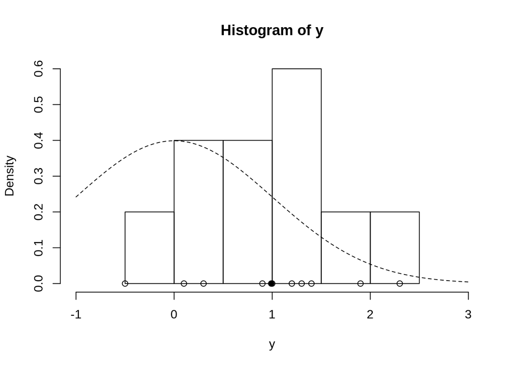

```r
y = c(1.2, 1.4, -0.5, 0.3, 0.9, 2.3, 1.0, 0.1, 1.3, 1.9) #andmed
ybar = mean(y)
n = length(y)

## prior
prior = list() #tühi list
prior$mu_0 = 0.0 # paneme priori mu 0
prior$sig2_0 = 1.0 # see on pmtslt meie enesekindlus esialgse prior keskmise mu_0 osas. See on 1, et oleks varsemas näites sarnane t jaotusega.

#Need kaks siin on vahe numbrid, millest tuletame Inverse Gama parameetrid. Kasutame selleks, et oleks kergem mõtestada, millest IG parameetrid koosnevad täpselt ja mida me valime, kui me valime IG parameetreid.
prior$n_0 = 2.0 # prior effective sample size for sig2
prior$s2_0 = 1.0 # prior point estimate for sig2

#Järgmised kaks parameetrid määravad prior jaotuse sigma jaoks. See prior jaotus on "Scaled inverse chi-squared distribution". Need lähtuvalt kahest eelnevast valitud parameetrist n_0 ja s2_0. Valem on alati sama. Need on pmtslt prioriks valitud Inverse-Gamma jaotuse parameetrid, mis on tuletatud prior effective sample size-ist ja sig2 point estimate'ist üleval.
prior$nu_0 = prior$n_0 / 2.0 # prior parameter for inverse-gamma (meie pakutav tõeline sigma 2)
prior$beta_0 = prior$n_0 * prior$s2_0 / 2.0 # prior parameter for inverse-gamma (kui kindlad me oma pakutavas sigma2-s oleme)

hist(y, freq=FALSE, xlim=c(-1.0, 3.0)) # histogram of the data
curve(dnorm(x=x, mean=prior$mu_0, sd=sqrt(prior$sig2_0)), lty=2, add=TRUE) # prior for mu
points(y, rep(0,n), pch=1) # individual data points
points(ybar, 0, pch=19) # sample mean
```

Järgmiseks jooksutame sämplerit

```r
set.seed(53)

init = list()
init$mu = 0.0 #Valime algseks väärtuseks 0
post = gibbs(y=y, n_iter=5e3, init=init, prior=prior)
```

```r
head(post)
```

```
##             mu      sig2
## [1,] 0.3746992 1.5179144
## [2,] 0.4900277 0.8532821
## [3,] 0.2536817 1.4325174
## [4,] 1.1378504 1.2337821
## [5,] 1.0016641 0.8409815
## [6,] 1.1576873 0.7926196
```

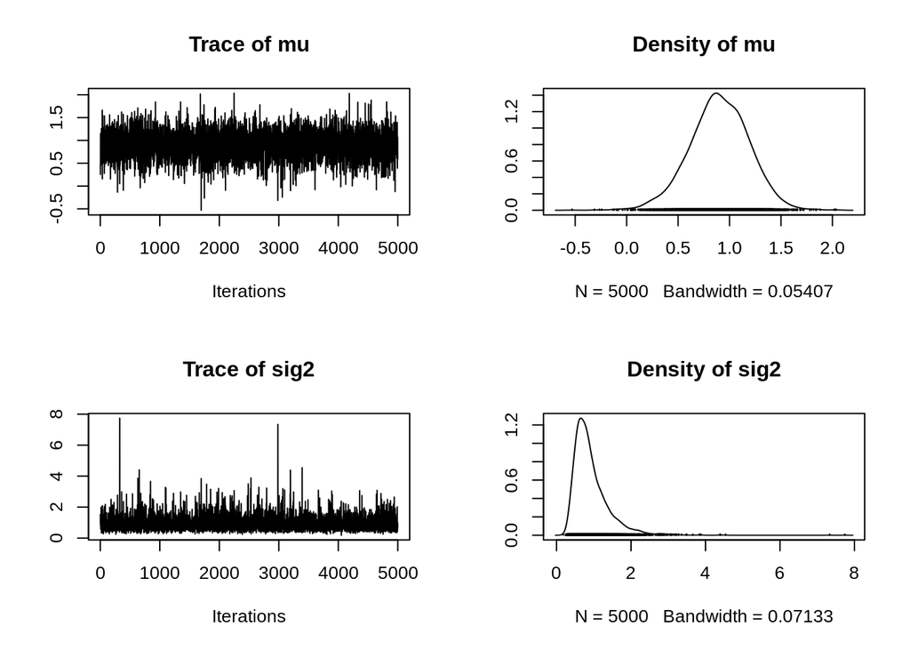

```r
library("coda")
plot(as.mcmc(post))
```

```r
summary(as.mcmc(post))
```

```
##
## Iterations = 1:5000
## Thinning interval = 1
## Number of chains = 1
## Sample size per chain = 5000
##
## 1. Empirical mean and standard deviation for each variable,
##    plus standard error of the mean:
##
##        Mean     SD Naive SE Time-series SE
## mu   0.9003 0.2883 0.004078       0.004078
## sig2 0.9258 0.4843 0.006849       0.007451
##
## 2. Quantiles for each variable:
##
##        2.5%    25%    50%   75% 97.5%
## mu   0.3026 0.7177 0.9017 1.093 1.440
## sig2 0.3765 0.6097 0.8076 1.105 2.169
```